# Brand and product Reviews

Ishwarya keerthivasan

2025-09-22

# **Why This Project Was Created (Business Need)**

In today’s digital-first world, brands and products are continuously being discussed on social media and review platforms. Customers openly share positive experiences, frustrations, and suggestions online. For businesses, this feedback is a **strategic asset**—it can highlight reputation risks, inform marketing campaigns, and guide product improvements.

The challenge is scale: the **volume of unstructured text data** is too large for manual analysis. Automated approaches such as sentiment analysis and machine learning enable organizations to monitor **brand reputation** and **customer sentiment** in real time. This project was created to demonstrate how these methods can be applied effectively to real-world brand and product reviews.

## Install and load required package:

```r
# Install/load required packages
required <- c("tidyverse","tidytext","caret","glmnet","Matrix",
              "ggplot2","scales","doParallel", "xgboost")
installed <- installed.packages()[, "Package"]
if(length(setdiff(required, installed)) > 0) install.packages(setdiff(required, installed))

library(tidyverse)
library(tidytext)
library(caret)
library(glmnet)
library(Matrix)
library(ggplot2)
library(scales)
library(doParallel)
```

## **Load and inspect the data**

```r
`Brand and product review tweet` <- read.csv("C:/Users/Ishwa/Downloads/Brand and product review tweet.csv")

# dataset load step
tweets_df <- `Brand and product review tweet`
colnames(tweets_df) <- c("tweet_text", "target", "emotion")
glimpse(tweets_df)
```

```
## Rows: 9,092
## Columns: 3
## $ tweet_text <chr> ".@wesley83 I have a 3G iPhone. After 3 hrs tweeting at #RI…
## $ target     <chr> "iPhone", "iPad or iPhone App", "iPad", "iPad or iPhone App…
## $ emotion    <chr> "Negative emotion", "Positive emotion", "Positive emotion",…
```

```r
# Count unique values per column
sapply(tweets_df, n_distinct)
```

```
## tweet_text     target    emotion
##       9065         10          4
```

## **Sentiment Distribution Per Brand**

```r
# Top 10 brands/products mentioned
top_10_brands <- tweets_df %>%
  filter(!is.na(target), target != "") %>%
  count(target, sort = TRUE) %>%
  top_n(10)
```

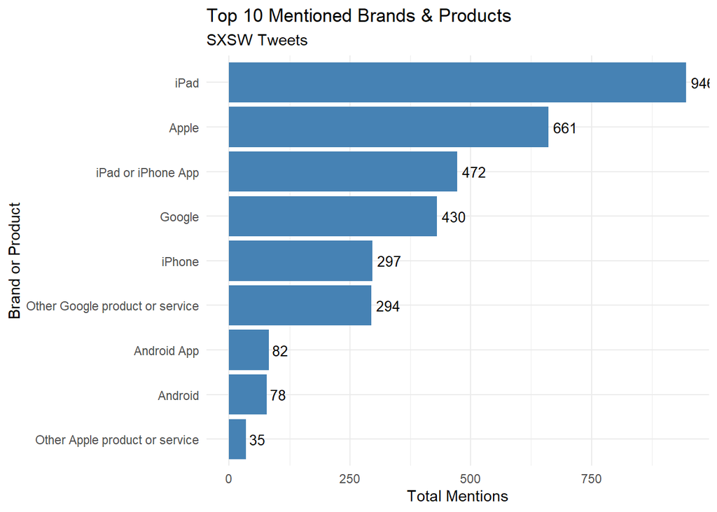

```r
ggplot(top_10_brands, aes(x = reorder(target, n), y = n)) +
  geom_col(fill = "steelblue") +
  geom_text(aes(label = n), hjust = -0.2, size = 3.5) +
  coord_flip() +
  labs(title = "Top 10 Mentioned Brands & Products",
       subtitle = "SXSW Tweets",
       x = "Brand or Product",
       y = "Total Mentions") +
  theme_minimal()
```

## **Clean and Consolidate Brand Categories**

```r
tweets_cleaned <- tweets_df %>%
  mutate(
    brand = case_when(
      grepl("apple|ipad|iphone", target, ignore.case = TRUE) ~ "Apple",
      grepl("google|android", target, ignore.case = TRUE) ~ "Google",
      target == "" ~ "Unspecified",
      TRUE ~ "Other"
    )
  )

table(tweets_cleaned$brand)
```

```
##
##       Apple      Google Unspecified
##        2411         884        5797
```

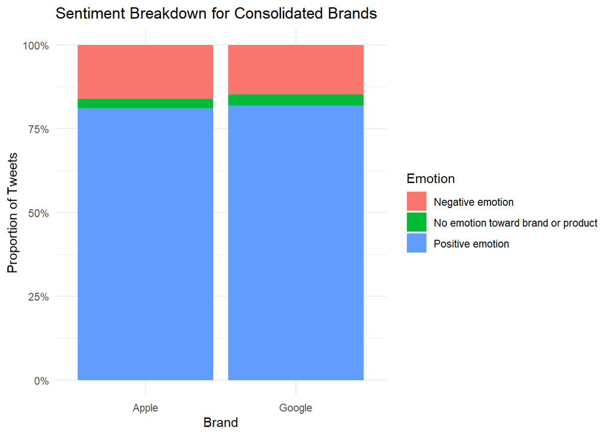

```r
tweets_cleaned %>%
  filter(brand != "Unspecified",
         emotion != "I can't tell") %>%
  count(brand, emotion) %>%
  ggplot(aes(x = brand, y = n, fill = emotion)) +
  geom_col(position = "fill") +
  scale_y_continuous(labels = percent) +
  labs(title = "Sentiment Breakdown for Consolidated Brands",
       x = "Brand",
       y = "Proportion of Tweets",
       fill = "Emotion") +
  theme_minimal()
```

## **Lexicon-Based Sentiment Analysis**

```r
# Tokenize + join with Bing lexicon
tweet_sentiments <- tweets_df %>%
  mutate(tweet_id = row_number()) %>%
  unnest_tokens(word, tweet_text) %>%
  inner_join(get_sentiments("bing"), by = "word")

# Sentiment score per tweet
sentiment_scores <- tweet_sentiments %>%
  count(tweet_id, sentiment) %>%
  pivot_wider(names_from = sentiment, values_from = n, values_fill = 0) %>%
  mutate(sentiment_score = positive - negative)

# Join back to original
final_sentiments <- tweets_df %>%
  mutate(tweet_id = row_number()) %>%
  left_join(sentiment_scores, by = "tweet_id") %>%
  mutate(sentiment_score = ifelse(is.na(sentiment_score), 0, sentiment_score))

# Most positive/negative tweets
final_sentiments %>%
  arrange(desc(sentiment_score)) %>%
  select(tweet_text, sentiment_score) %>%
  head(5)
```

```
##                                                                                                                                              tweet_text
## 1                                  Can't be at  #SXSW ? well this is a nice (free) booby prize... Featured Artists - {link} #iTunes #free via  @mention
## 2 wow! major win for you! \x89\xdb\xcf@mention traded the Xoom I won at the JS party for the iPad 2 @mention won #sxsw #winwin #winning #tigerblood\x89۝
## 3                Texas has been amazing I've met so many influential people that work at twitter, foursquare, Microsoft and even Apple.  #SXSW #Winning
## 4                                  Thanks to everyone who came by today. Good luck on winning the iPad. Stop by tomorrow for more chances to win. #sxsw
## 5          Well good morning #SxSWi day 4... I'm ready for another day of great panels, BC alumni &amp; the Industry Party tonight! #sxsw #gsdm #google
##   sentiment_score
## 1               5
## 2               5
## 3               4
## 4               4
## 5               4
```

```r
final_sentiments %>%
  arrange(sentiment_score) %>%
  select(tweet_text, sentiment_score) %>%
  head(5)
```

```
##                                                                                                                                    tweet_text
## 1                  If iPhone alarms botch the timechange, how many #SXSW'ers freak? Late to flights, missed panels, behind on bloody marys...
## 2    I composed a tweet so acerbic and cynical about ipad users that my phone crashed and dumped all my apps. #twitterpower #sxsw #imthatgood
## 3                                       RIP my iPhone 4: June 2010 -  #SXSW. You survived a severe drop, but could not evade drowning. {link}
## 4                        If a bomb goes off in this convention center, Apple is going to lose a devastating share of it's customer base #sxsw
## 5 Length of Google penalty based on severity of breach of webmaster guidelines. i.e.white text on white bgr might get 30 day pen. #sxsw #qagb
##   sentiment_score
## 1              -4
## 2              -4
## 3              -4
## 4              -3
## 5              -3
```

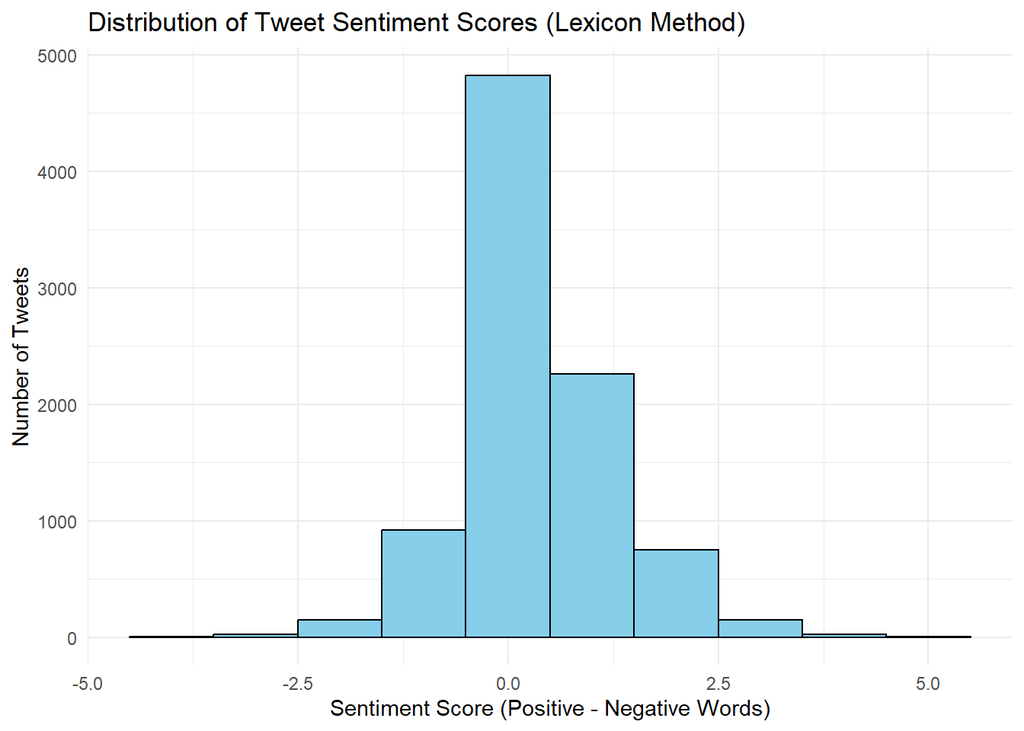

```r
# Distribution
ggplot(final_sentiments, aes(x = sentiment_score)) +
  geom_histogram(binwidth = 1, fill = "skyblue", color = "black") +
  labs(title = "Distribution of Tweet Sentiment Scores (Lexicon Method)",
       x = "Sentiment Score (Positive - Negative Words)",
       y = "Number of Tweets") +
  theme_minimal()
```

## **Brand-Specific Sentiment (Lexicon)**

```r
brand_sentiments <- tweets_cleaned %>%
  select(tweet_text, brand) %>%
  mutate(tweet_id = row_number()) %>%
  inner_join(final_sentiments %>% select(tweet_id, sentiment_score), by = "tweet_id")

average_brand_sentiment <- brand_sentiments %>%
  filter(brand %in% c("Apple","Google")) %>%
  group_by(brand) %>%
  summarise(average_score = mean(sentiment_score, na.rm = TRUE),
            total_tweets = n())

average_brand_sentiment
```

```
## # A tibble: 2 × 3
##   brand  average_score total_tweets
##   <chr>          <dbl>        <int>
## 1 Apple          0.495         2411
## 2 Google         0.637          884
```

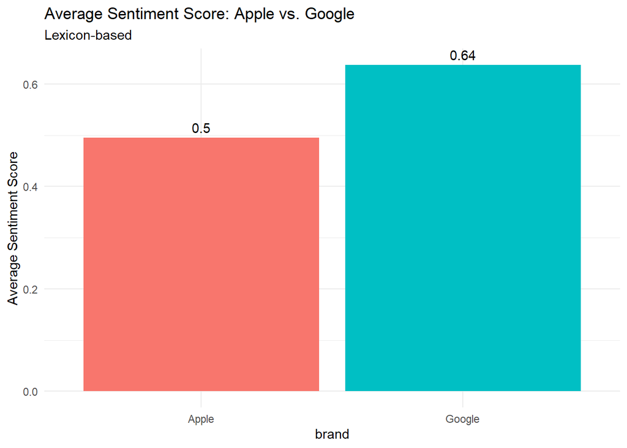

```r
ggplot(average_brand_sentiment, aes(x = brand, y = average_score, fill = brand)) +
  geom_col(show.legend = FALSE) +
  geom_text(aes(label = round(average_score,2)), vjust = -0.5) +
  labs(title = "Average Sentiment Score: Apple vs. Google",
       subtitle = "Lexicon-based",
       y = "Average Sentiment Score") +
  theme_minimal()
```

## **Machine Learning Approach: TF-IDF + XGBoost**

```r
install.packages("xgboost")
library(xgboost)
# Filter relevant classes
model_data <- tweets_cleaned %>%
  filter(emotion %in% c("Positive emotion",
                        "Negative emotion",
                        "No emotion toward brand or product")) %>%
  mutate(emotion = factor(emotion),
         tweet_id = row_number())

# --- TF-IDF Features ---
dtm_tfidf <- model_data %>%
  unnest_tokens(word, tweet_text) %>%
  anti_join(stop_words, by = "word") %>%
  count(tweet_id, word) %>%
  bind_tf_idf(word, tweet_id, n) %>%
  cast_sparse(tweet_id, word, tf_idf)

labels <- model_data$emotion
num_classes <- nlevels(labels)

# --- Train/Test Split ---
set.seed(123)
train_index <- createDataPartition(labels, p = 0.7, list = FALSE)

train_x <- dtm_tfidf[train_index, ]
test_x  <- dtm_tfidf[-train_index, ]

train_y <- labels[train_index]
test_y  <- labels[-train_index]

# Convert to xgboost format
dtrain <- xgb.DMatrix(data = train_x, label = as.numeric(train_y) - 1)
dtest  <- xgb.DMatrix(data = test_x,  label = as.numeric(test_y) - 1)

# --- Train XGBoost Model ---
params <- list(
  objective = "multi:softprob",
  num_class = num_classes,
  eval_metric = "mlogloss",
  max_depth = 6,
  eta = 0.2,
  subsample = 0.8,
  colsample_bytree = 0.8
)

xgb_model <- xgb.train(
  params = params,
  data = dtrain,
  nrounds = 300,
  watchlist = list(train = dtrain, eval = dtest),
  early_stopping_rounds = 15,
  verbose = 1
)
```

[output not shown]

```r
# Probabilities → choose class with max prob
pred_probs <- predict(xgb_model, dtest)
preds <- max.col(matrix(pred_probs, ncol = num_classes, byrow = TRUE))
preds_factor <- factor(preds, levels = 1:num_classes, labels = levels(labels))

confusionMatrix(preds_factor, test_y)
```

```
## Confusion Matrix and Statistics
##
##                                     Reference
## Prediction                           Negative emotion
##   Negative emotion                                 18
##   No emotion toward brand or product              112
##   Positive emotion                                 41
##                                     Reference
## Prediction                           No emotion toward brand or product
##   Negative emotion                                                   10
##   No emotion toward brand or product                               1423
##   Positive emotion                                                  183
##                                     Reference
## Prediction                           Positive emotion
##   Negative emotion                                  6
##   No emotion toward brand or product              525
##   Positive emotion                                362
##
## Overall Statistics
##
##                Accuracy : 0.6728
##                  95% CI : (0.6546, 0.6905)
##     No Information Rate : 0.603
##     P-Value [Acc > NIR] : 4.664e-14
##
##                   Kappa : 0.293
##
##  Mcnemar's Test P-Value : < 2.2e-16
##
## Statistics by Class:
##
##                      Class: Negative emotion
## Sensitivity                         0.105263
## Specificity                         0.993623
## Pos Pred Value                      0.529412
## Neg Pred Value                      0.942177
## Prevalence                          0.063806
## Detection Rate                      0.006716
## Detection Prevalence                0.012687
## Balanced Accuracy                   0.549443
##                      Class: No emotion toward brand or product
## Sensitivity                                             0.8806
## Specificity                                             0.4013
## Pos Pred Value                                          0.6908
## Neg Pred Value                                          0.6887
## Prevalence                                              0.6030
## Detection Rate                                          0.5310
## Detection Prevalence                                    0.7687
## Balanced Accuracy                                       0.6409
##                      Class: Positive emotion
## Sensitivity                           0.4054
## Specificity                           0.8747
## Pos Pred Value                        0.6177
## Neg Pred Value                        0.7464
## Prevalence                            0.3332
## Detection Rate                        0.1351
## Detection Prevalence                  0.2187
## Balanced Accuracy                     0.6400
```

```r
install.packages("MLmetrics")
library(MLmetrics)
F1_Score(y_pred = preds_factor, y_true = test_y, positive = "Negative emotion")
```

```
## [1] 0.1756098
```

```r
F1_Score(y_pred = preds_factor, y_true = test_y, positive = "Positive emotion")
```

```
## [1] 0.4895199
```

## **5. Business Impact**

This type of analysis enables organizations to:  
- **Track Brand Reputation** in real-time and react proactively.  
- **Benchmark Against Competitors** to understand relative market perception.  
- **Improve Customer Experience** by identifying recurring complaints or praise.  
- **Support Marketing Strategy** by amplifying positive sentiment and addressing negative feedback effectively.

## **6. Next Steps**

While traditional models provide a useful baseline, **transformer-based models such as BERT** offer significantly better performance by capturing language context, sarcasm, and slang. Future work can involve:  
- Fine-tuning BERT on this dataset for improved emotion classification.  
- Building an interactive **dashboard** for real-time sentiment monitoring.  
- Integrating results with **business intelligence tools** to support decision-making.

## **7. Closing Statement**

This project demonstrates how sentiment analysis can turn unstructured text into **actionable insights** for businesses. By combining exploratory analysis, lexicon-based scoring, and predictive modeling, organizations can better understand how customers feel about their brands and products. Ultimately, this empowers decision-makers to respond effectively, improve customer satisfaction, and strengthen competitive positioning.